# Answer for Session1 part2: data summary

MRC London Institute of Medical Sciences (http://bioinformatics.lms.mrc.ac.uk)

25/Sep/2019

These exercises cover the sections of Statistics in R.

**Exercise 2**

- Use the `pnorm()` function to see the probablity of a value being less than or equal to 2 for a normal distribution of mean 0 and standard deviation 1

```r
 pnorm(2,mean=0,sd=1)
```

```
## [1] 0.9772499
```

- What is the probablity of a value being bigger than 2 for a normal distribution of mean 0 and standard deviation 1 (hint: use `pnorm` in the Console and read the “help” tab in the lower right panel)

```r
# option 1
  pnorm(2,mean=0,sd=1,lower.tail = F)
```

```
## [1] 0.02275013
```

```r
# option 2
  1-pnorm(2,mean=0,sd=1)
```

```
## [1] 0.02275013
```

**bonus question (optional)**

- load the gene expression matrix that has been created for this exercise from `"data/gene_exp_matrix.RData"`

```r
load("../data/gene_exp_matrix.RData")
head(gene_exp_matrix)
```

```
##         Control1 Control2 Treatment1 Treatment2
## Pam     5.484927 5.523276   5.894180   5.981405
## Slco6d1 7.390315 7.259712   7.963158   7.751687
## Rnf152  7.018605 6.964135   7.364457   7.298354
## Cpa6    8.289773 8.116202   8.705973   8.677886
## Dsel    4.561322 4.548146   4.950947   4.850020
## Tsn     8.779546 8.814279   9.412200   9.488729
```

- use the gene expression to draw a heatmap

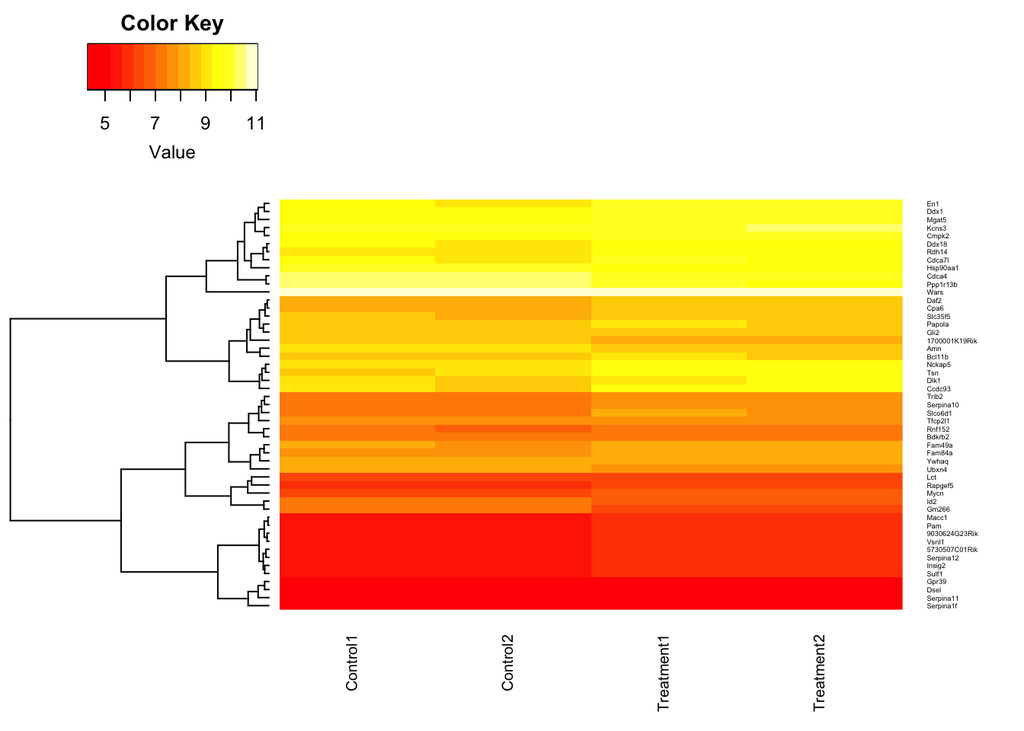

```r
#install.packages("gplots")
library("gplots")
heatmap.2(gene_exp_matrix,symkey=FALSE, trace="none",cexCol=0.75,cexRow=0.35,
          density.info="none",Colv = F,dendrogram="row")
```

- Use the `scale()` function to perform the Z-score transformation, and use the code above to generate the heatmap again (hint: read the help page of `?scale`, and you might need to use `t()` function as well)

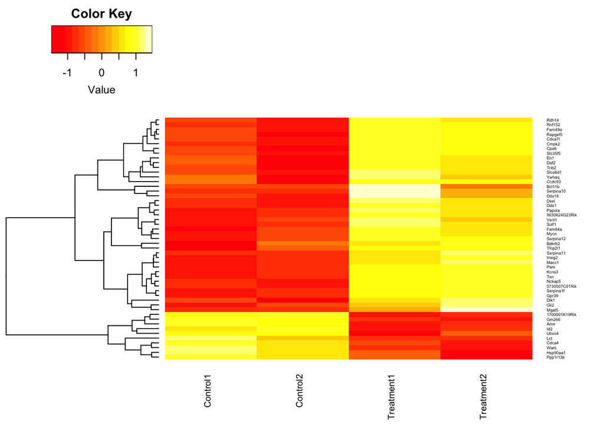

```r
# option 1
scaled_gene_exp_matrix<-t(scale(t(gene_exp_matrix)))
heatmap.2(scaled_gene_exp_matrix,symkey=FALSE, trace="none",cexCol=0.75,cexRow=0.35,
          density.info="none",Colv = F,dendrogram="row")
```

However, the `heatmap.2()` function has a argument called `scale`, which does the same thing for you….